# Adverse Event Mining From Twitter

Julia Gyorffy, Alexander Noll, Tianhui Shi, Karma Tarap

04 May 2016

# Motivation

Adverse Drug Reactions (ADRs) are harmful effects caused by the intake of a medical drug and represent a significant societal health problem. According to the FDA Adverse Effects Reporting system the number of hospitalizations and even deaths caused by ADRs is ever increasing and has [reached over one million cases in the US as of 2014](http://www.fda.gov/Drugs/GuidanceComplianceRegulatoryInformation/Surveillance/AdverseDrugEffects/ucm070434.htm). This corresponds to [5% of hospital visits, 28% of emergency visits and 5% of hospital deaths](http://diego.asu.edu/Publications/ADRClassify.html).

Thus, the detection of these events plays a significant role for improving human health. The assessment and detection of adverse reactions for prescription drugs starts at the clinical trial level and continues after market release through national reporting tools that allow manufacturers and the public to report on ADRs. However, due to the limitations of clinical trials and the voluntary nature of public reporting tools, the actual detection of the adverse reactions is incomplete and not timely.

With the [massive increase of social media](http://www.pewinternet.org/fact-sheets/social-networking-fact-sheet/) usage over the past years, where patients share information about diseases, symptoms and treatments, social networks can represent an alternative source to identify ADRs from user generated data.

While social media offers new opportunities for health monitoring, it also brings about unique challenges. Due to its free-text nature, the data is rather unstructured and informal, containing a high level of misspellings or colloquialisms which makes natural language processing and algorithm applications difficult. Identifying ADRs terms is an additional challenge because often the information published can be irrelevant to an actual treatment or personal experience or it might even be commercial information about a drug. Additionaly, the effects of a drug mentioned can either be an adverse reaction or a beneficial one, and the diversity of informal terms used are hard to match with adverse effects lexicon terms.

## Project goals

While different social platforms are used to exchange health information, such as communities, blogs, forums etc. for this project we chose to focus on twitter as a source for health-related information. There are [1.3 billion registered users and 310 million people that use Twitter with 120 million unique visitors per month](https://about.twitter.com/company).

In the first place we wanted to investigate the possibilities for retrieving twitter data containing drug related information.

Considering the challenges of unstructured data we wanted to find ways of dealing with spelling errors, slang words, match with ADR lexicon terms, extracting hashtags and URLs.

And lastly, we wanted investigate whether machine learning techniques trained on older data to predict an ADR can also be applied to current data. This question is of critical importance because if the language or content in social media change so drastically over few years that models trained on old data are not valid anymore, it would mean that experts have to annotate quite large amounts of tweets on a regular basis to have valid training samples.

## Methodology

#### Data Collection

For the analysis we used both secondary as well as primary twitter data. As secondary data we used two twitter corpora collected from the paper by [Nikfarjam et al: Pharmacovigilance from social media: mining adverse drug reaction mentions using sequence labeling with word embedding cluster features](http://www.ncbi.nlm.nih.gov/pubmed/25755127) and from [Abeed Sarker and Graciela Gonzalez. Portable automatic text classification for adverse drug reaction detection via multi-corpus training. Journal of Biomedical Informatics. 53 (2015) 196-207.](http://diego.asu.edu/Publications/ADRClassify.html). This data contained tweet ids and tweet annotations. We could then use the tweet id to retrieve the actual tweets using a python script provided by the authors.

To collect primary twitter data the same drug list was used as in the paper by Nikfarjam et al. All tweets in english starting from January 2016 containing the listed drug names were been retrieved using Twitter’s application programming interface and the R twitterR package.

#### Data analysis

Using the secondary data we first investigated the proportion of ADR related words versus the non-ADR related words by doing exploratory data analysis using, e.g. wordclouds and sentiment analysis.

We then applied data cleaning methods to the existing and newly retrieved data:

- replace slang expression and expressions using a dictionary
- spellchecking and replacing words
- more standard NLP techniques like word stemming

As a next step we applied machine learning techniques to investigate if models for predicting ADRs on data generated in 2013 still applied to data retrieved today. Different sets of features were explored:

- Bag of words using term frequency
- Bag of words using term frequency / inverse document frequency
- sentiment analysis
- wheter the tweet contains a URL (related to advertisments)
- length of the tweet

To deal with this question we first trained models on the secondary data sets. We then applied the models to the primary data to validate the models. As an evaluation metric we chose to use area under curve, which is a fairly common measure.

## Results

The results on the secondary dataset were good (area under curve around 85%) and comparable to results mentioned in previous research. The data cleaning steps spell-checking and slang-replacement gave advantages over using just standard NLP techniques (especially on models before stacking: there they gave an improvement in AUC of around 5%, in the stacked model around 2%). The results on the recent data were considerably lower. The most likely reason is that even manually annotating tweets is difficult and our methodology was different from the researchers’ in the references.

# Data collection

## Data used in previous studies

Twitter Corpus was downloaded from [here](http://diego.asu.edu/Publications/ADRMine.html) and [here](http://diego.asu.edu/downloads/twitter_annotated_corpus/).

The first is the Corpus referred to in the paper by [Nikfarjam et al: Pharmacovigilance from social media: mining adverse drug reaction mentions using sequence labeling with word embedding cluster features](http://www.ncbi.nlm.nih.gov/pubmed/25755127) and the second one comes from [Abeed Sarker and Graciela Gonzalez. Portable automatic text classification for adverse drug reaction detection via multi-corpus training. Journal of Biomedical Informatics. 53 (2015) 196-207.](http://diego.asu.edu/Publications/ADRClassify.html)

The first corpus contains the following files: - Test tweet annotations - Test tweet ids - Train tweet annotations - Train tweet ids - Program to download tweets

The second corpus consists of two files: - Tweet ids - Program to download tweets

For data confidentiality reasons, the researchers had not made the individual tweets available. However, they had provided a python script that would retreive the Tweets from the tweed id. To maintain the confidentiality, we have made our github area private.

The download of the dataset is not executed by default.

```r
# Download dataset; not executed by default
system("python ../data/download_tweets/download_tweets.py ../data/download_tweets/train_tweet_ids.tsv ../data/download_tweets/full_train_tweet_ids.tsv")
system("python ../data/download_tweets/download_tweets.py ../data/download_tweets/test_tweet_ids.tsv ../data/download_tweets/full_test_tweet_ids.tsv")
system("python ../data/download_tweets/download_tweets.py ../data/download_tweets/Twitter_corpus_releaseset_external.txt ../data/download_tweets/binary_tweets_downloaded.tsv")
```

## Script for collection new data

In the following, we download tweets containing the drug names listed below. The data collection was performed on April 21.

```r
setup_twitter_oauth("consumer_key", "consumer_secret",
                    "access_token", "access_secret")

drugs<-c("humira",
         "dronedarone",
         "lamictal",
         "pradaxa",
         "paxil",
         "zoledronic acid",
         "trazodone",
         "enbrel",
         "cymbalta",
         "quetiapine",
         "cipro",
         "lozenge",
         "dabigatran",
         "olanzapine",
         "fluoxetine",
         "vyvanse",
         "seroquel",
         "fosamax",
         "paroxetine",
         "nicotine",
         "effexor",
         "prozac",
         "tysabri",
         "rivaroxaban",
         "baclofen",
         "lamotrigine",
         "venlafaxine",
         "apixaban",
         "avelox",
         "levaquin",
         "zyprexa",
         "duloxetine",
         "ofloxacin",
         "geodon",
         "victoza",
         "metoprolol",
         "viibryd",
         "pristiq",
         "nesina",
         "factive",
         "gamma-aminobutyric acid",
         "sabril",
         "livalo",
         "denosumab",
         "bystolic",
         "xarelto",
         "floxin",
         "boniva",
         "saphris",
         "ziprasidone",
         "memantine",
         "namenda",
         "latuda",
         "fycompa",
         "canagliflozin",
         "zometa",
         "etanercept",
         "lurasidone",
         "alendronate",
         "linagliptin",
         "effient",
         "vimpat",
         "eliquis",
         "liraglutide",
         "pregabalin",
         "onglyza",
         "nicotrol inhaler",
         "lyrica",
         "invokana",
         "commitlozenge",
         "actonel",
         "nicotrolinhaler",
         "synthroid",
         "albuterol",
         "nasonex",
         "spiriva",
         "suboxone",
         "nexium",
         "januvia",
         "valsartan",
         "tamiflu"
         )

tweets = list()
for(i in 1:length(drugs)) {
  result <- searchTwitter(drugs[i],
                          n = 1500,
                          lang = "en",
                          since = "2016-01-01")
  Sys.sleep(60)
  tweets <- c(tweets,result)
  tweets <- unique(tweets)
}

save(tweets, file = "../data/download_tweets/datacollection.RData")
```

To be able to manually annotate some of the new tweets, we converted them into tabular form: a data frame having two columns:

- tweet_id
- tweet_text

Furthermore, we saved a sample of 400 tweets as an Excel file for easier annotation.

```r
set.seed(123)
parse_new_tweets <- function(tweets) {
    tweets_text <- tweets %>% map_chr(~.$text)
    tweets_id <- tweets %>% map_chr(~.$id)

    data_frame(tweet_id = tweets_id,
               tweet_text = tweets_text)
}

write.xlsx(parse_new_tweets(tweets) %>% sample_n(400),
           file = "../data/download_tweets/tweets_for_annotation.xlsx")
```

Due to problems with encoding, we had to erase 5 tweets from the Excel file leaving us with 395 tweets for manual annotation.

# Data cleaning

## Read the data

In the following, we define a function that reads the corpus from [Nikfarjam et al]: for each tweet it contains detailed information about the adverse event.

The steps consists of

1. Parse the annotation file and label the columns
2. Read the dataset obtained from executing the Python script mentioned in the previous section:
3. Read the Adverse Drug reaction lexicon
4. combine all results

```r
#' Parse downloaded annotated data
#'
#' @description Parses the data from the DIEGO labs. Depending on the argument
#' it reads in the training or test data. It joins the tweets with the
#' annotations. Empty annotations means no adverse reaction.
#'
#' @param type = c("train", "test")
#'
#' @return data frame
#'
#' @examples parse_diego_data("train")
#' @import dplyr, magrittr, readr, stringr

parse_diego_data <- function(type) {
    # Load data
    annotation_file <-
        ifelse(type == "train",
               "../data/download_tweets/train_tweet_annotations.tsv",
               ifelse(type == "test",
                      "../data/download_tweets/test_tweet_annotations.tsv",
                      stop("type should be either 'train' or 'test'"
                      ))
               )

    tweets_file <-
        ifelse(type == "train",
               "../data/download_tweets/full_train_tweet_ids.tsv",
               ifelse(type == "test",
                      "../data/download_tweets/full_test_tweet_ids.tsv",
                      stop("type should be either 'train' or 'test'"))
               )

    # Read annotations and rename columns
    annotations <-
        read_tsv(annotation_file,
                 col_names = FALSE,
                 col_types = c("ciicccc")
        ) %>%
        rename(text_id = X1,
               start_offset = X2,
               end_offset = X3,
               semantic_type = X4,
               annotated_text = X5,
               related_drug = X6,
               target_drug = X7
        )

    # Parse tweets
    tweets <-
        read_lines(tweets_file) %>%
        str_split(., "\t") %>%
        as.data.frame() %>%
        as.matrix() %>%
        t %>%
        as.data.frame() %>%
        `rownames<-`(., NULL) %>%
        rename(tweet_id = V1,
               user_id = V2,
               text_id = V3,
               tweet_text = V4
        )

    # Read in the ADR lexicon and rename
    adr_lexicon <- read_tsv("../data/download_tweets/ADR_lexicon.tsv",
                            skip = 21,
                            col_names = FALSE) %>%
        rename(concept_id = X1,
               concept_name = X2,
               source = X3)

    # Join tweets and annotations
    result <-
        suppressWarnings(left_join(tweets, annotations, by = "text_id"))

    # Join result with ADR lexicon
    result <- left_join(result,
                        adr_lexicon,
                        by = c("annotated_text" = "concept_name"))

    # Select distinct tweets
    result <- result %>% distinct(tweet_id)

    result[ ] <- lapply(result, as.character)

    result
}
```

Next, we define a similar function that reads in the data from [Abeed Sarker and Graciela Gonzalez]. Reading this dataset is easier and just consists of reading the dataset obtained from executing the Python script.

```r
#' Parse binary data
#'
#' @description Parses the data with binary annotation¨
#'
#' @return data frame
#'
#' @examples parse_binary_data()
#' @import dplyr, purrr, readr, stringr

parse_binary_data <- function(type) {
    # Load data
    tweets_file <- "../data/download_tweets/binary_tweets_downloaded.tsv"

    # Parse tweets: bad character "\r" has to be removed before the string
    # can be split
    individual_tweets <-
        read_file(tweets_file) %>%
        str_replace_all("\r", "") %>%
        str_split(., "\n") %>%
        unlist()

    # Split the tweets and have four output columns
    # Revalue is_AE column (needed for caret to work with some ML algos)
    tweets_frame <-
        individual_tweets %>%
        str_split_fixed("\t", 4) %>%
        as.data.frame() %>%
        rename(tweet_id = V1,
               user_id = V2,
               is_AE = V3,
               tweet_text = V4
        ) %>%
        filter(is_AE != "") %>%
        mutate(is_AE = as.factor(plyr::revalue(is_AE,
                                               c("0" = "No", "1" = "Yes"))
                                 ))
    tweets_frame[ ] <- lapply(tweets_frame, as.character)

    tweets_frame
}
```

Now that we have defined the functions reading in the data, let us take a first look at them to get a feeling.

## First look at the data

```r
# Read in the training data
train.data <- parse_diego_data("train")
test.data <- parse_diego_data("test")
binary.data <- parse_binary_data()
```

We can see from the tweets that we might want to extract the drug names “humira” to use as a feature in future models. Even though the researchers have annotated the drug names on this dataset, this should help us classify non-annotated tweets. This could serve the puropse of **automatically** creating new training sets:

If we want to predict ADRs on new drugs, our trained model should not have the drug name we are interested in included as feature. For the purpose of generating a new training sample, this could, however, be a good strategy, although one has to be careful with bias.

```r
train.data$tweet_text[709]
```

```
## [1] "Humira is kicking in again which is nice but that also means I'm moving towards my next injection...\"AS\" the joy of joys, still smiling."
```

Although our sample of tweets, for the most part, were correctly spelt, we still wanted to run it through a spell checker to ensure our models were robust.

```r
train.data$tweet_text[318]
```

```
## [1] "@any1mouse jus Gt bck myself, hes puT me on citalopram in addition 2 the quetiapine! Im a bit worried as citalopram has made me manic before"
```

We can also see a few examples of internet slang usage. This is hard for a spell checker to correct so we want to investigate if we can clean this up a bit.

```r
train.data$tweet_text[751]
```

```
## [1] "@evann_lfc yea still a vampire as still on cipro wbu? Xx"
```

A further challenge we see is that there is sometimes repeats of characters to show emphasis. This will need to be corrected also.

```r
train.data$tweet_text[807]
```

```
## [1] "@kaliruoff ohhh...lmao that's just great. Maybe it was probably seroquel. That stuff knocks you outttttttt haha"
```

## Drug names

The drug names were downloaded from [here](https://www.nlm.nih.gov/research/umls/rxnorm/docs/rxnormfiles.html).

These are stored as `./data/dictionaries/RXNCONSO.RFF`.

We create a function that makes a list of drugs so we can identify tweets containing a known drug name, as well as ignore them from spell checking. We restrict to brand names (BN) and generics / ingredients (IN)

```r
make_drug_list <- function() {
    # Read drug names
    rx.conso <- read.delim(file = '../data/dictionaries/RXNCONSO.RRF',
                       sep='|',
                       header = F,
                       stringsAsFactors = F)

    # Column names
    rx.colstr <- "RXCUI LAT TS LUI STT SUI SPREF RXAUI SAUI SCUI SDUI SAB TTY CODE STR SRL SUPPRESS CVF"

    # Assign column names to data frame
    names(rx.conso) <- rx.colstr %>%
        tolower %>%
        strsplit(split=' ') %>%
        unlist

    # Subset a list of drug brand names (BN) and generics/ingredient name (IN)
    # convert to lower for easier lookup
    drug.list <- rx.conso %>%
        subset((tty %in% c('BN','IN'))) %>%
        select(tty, code, str) %>%
        mutate(str = tolower(str))

    drug.list
    }
```

## Slang words

The idea in this step is to clean slang expression and convert then to proper english as well as possible. This is done before passing the tweets to the spellchecker.

Slang words were scraped from [here](http://www.netlingo.com/acronyms.php).

Again, we write a function that makes the conversion table:

```r
make_slang_lookup <- function() {
    url <- "http://www.netlingo.com/acronyms.php"

    contents <- read_html(url)

    #write(contents, file = "../data/dictionaries/slang.txt")

    #contents <- read.table("../data/dictionaries/slang.txt")

    #lapply(contents, write, "../data/dictionaries/slang_words", append=TRUE, ncolumns=1000)

    # Using the chrome selector gadget we identified the following attributes containing the dictionary: .list_box3 li, .list_box3 span
    words <- contents %>%
        html_nodes(".list_box3 span") %>%
        html_text() %>% tolower

    descriptions <- contents %>%
        html_nodes(".list_box3 li") %>%
        html_text() %>% tolower

    slang.lookup <- data.frame(words, descriptions, stringsAsFactors = FALSE)

    # Cleaning out the descriptions, as it contains the slang words also
    # Also removing slangs that can have multiple interpretations
    # Remove the null key
    slang.lookup <- slang.lookup %>%
        mutate(decode = substring(descriptions,nchar(words)+1)) %>%
        filter(!grepl(",|-or-",descriptions)) %>%
        filter(words != "")
}
```

Next, we put every together: we add new attributes to the dataset

- We extract the **hastags**
- We see whether the tweet text contains a **URL**. This could be related to advertisments
- Add positive and negative sentiments
- Stem the text
- Extract drugs

```r
clean_tweets <- function(train.data, drug.list, slang.lookup) {

  #Loading the emoticon dataset from qdapDictionaries. This converts emoticons to their english text counterpart
  data("emoticon")

  train.data.new <- train.data %>%
    mutate(
      #ae_term       = substr(tweet_text,start_offset,end_offset),      # Extract ae terms (only applicable here)
      hashtag       = str_extract_all(tweet_text,"#[a-zA-Z]+"),        # Collect all hashtags
      URL           = grepl("http[[:alnum:][:punct:]]*", tweet_text)   # Boolean to indicate if tweet contains UR

    ) %>%
    arrange(tweet_id) %>%
    mutate(rown = row_number())


  # Reshaping the data
  # Transposing to get one word per row using unnest without removing punctuation. This allows us to preserve emoticons
  train.data.long <- train.data.new %>%
    select(tweet_id, tweet_text) %>%
    mutate(words = strsplit(as.character(tolower(tweet_text))," ")) %>%
    unnest() %>%
    group_by(tweet_id) %>%
    mutate(wordn = row_number()) %>%
    ungroup %>%
    left_join(emoticon, by=c("words"="emoticon"))             # Add the meaning for the emoticons from the emoticon dictionary


  train.data.aug <- train.data.long %>%
    mutate(
      is_hashtag = grepl("#[a-zA-Z]+",words),                 # attribute to show if its a hashtag
      is_URL     = grepl("http[[:alnum:][:punct:]]*",words),  # is it a url
      words      = gsub("([:lower:])\\1+","\\1\\1", words),   # Contract word length
      words      = gsub("[[:punct:]]", "", words)             # Remove punctuation
      ) %>%
    filter(words != "") %>%
    left_join(mutate(drug.list, drug_name=str), by=c("words"="str")) %>%
    left_join(slang.lookup, by="words")



  # this part runs really slow, be warned
  train.data.clean <- train.data.aug %>%
    rowwise() %>%
    mutate(
      words = ifelse((is.na(drug_name) && !is_hashtag && !is_URL),
             ifelse (hunspell_check(words),
                     words,
                     ifelse(is.na(decode),
                            hunspell_suggest(words)[[1]][1],
                            decode
                            )
                     ),
             words
             )
    )

  # aggregating the entire tweets back to one line per tweet
  train.data.wide <- train.data.clean%>%
    group_by(tweet_id) %>%
    summarise(cleaned_tweet = paste(words, collapse = " "))


  # Creating a corpus to create the term document matrix
  tweet.corpus <- Corpus(VectorSource(train.data.wide$cleaned_tweet))

  # Stem the words
  tweet.corpus <- tm_map(tweet.corpus, stemDocument)

  # Create the term document matrix, removing punctuation and stopwords (common words that carry little meaning)
  tdm <- TermDocumentMatrix(tweet.corpus,
                            control = list(
                                           removePunctuation = TRUE,
                                           stopwords = TRUE))


  # Generating a sentiment score to be used as a feature in the predictive model
  pos.score <- tm_term_score(tdm, terms_in_General_Inquirer_categories("Positiv")) # this lists each document with number below

  neg.score <- tm_term_score(tdm,terms_in_General_Inquirer_categories("Negativ"))


  cleaned_tweets <- data.frame(stemmed = sapply(tweet.corpus, as.character),
                               positive = pos.score,
                               negative = neg.score,
                               stringsAsFactors = FALSE)

  # Sentiment scoring
  cleaned_tweets <- cleaned_tweets %>%
    mutate(rown = row_number(),
           positivity = (positive - negative) / (positive + negative + 1))

  # merge this onto the original tweet dataset that other features for the predictive model
  cleaned_tweets <-
      cleaned_tweets %>%
      inner_join(train.data.new, by="rown")

  #Remove drugs from text
  drugs <-
      read_lines("../data/download_tweets/drug_names.txt", skip = 6) %>%
      stemDocument()
  drug_regex <- drugs %>% str_c(collapse = "|") %>% str_c("(", ., ")")

  # Remove hashtag symbol
  cleaned_tweets$hashtag %<>% str_replace_all("#", "")

  # Change hashtags
  cleaned_tweets$hashtag %<>% str_to_lower() %>% stemDocument()
  cleaned_tweets$hashtag <- plyr::revalue(cleaned_tweets$hashtag, c("character(0)" = NA))

  # Extract drug
  cleaned_tweets$drug <-
      str_c(str_extract_all(cleaned_tweets$stemmed, drug_regex),
            str_extract_all(cleaned_tweets$hashtag, drug_regex)) %>%
      str_replace_all("character\\(0\\)", "")

  # Remove drug from tweet and hashtag
  cleaned_tweets$stemmed %<>% str_to_lower %>%  str_replace_all(drug_regex, "")

  cleaned_tweets$hashtag %<>%
      str_replace_all(drug_regex, "") %>%
      str_replace_all('", ', "") %>%
      str_replace_all('c\\("', "") %>% str_replace_all('"\\)', "") %>%
      str_replace_all('\\"', " ") %>%
      ifelse(. == "", NA, .)

  cleaned_tweets
}

cleaned_train <- clean_tweets(train.data, make_drug_list(), make_slang_lookup())
cleaned_test <- clean_tweets(test.data, make_drug_list(), make_slang_lookup())
cleaned_binary <- clean_tweets(binary.data, make_drug_list(), make_slang_lookup())

save(cleaned_train,file="../data/cleaned_train.Rda")
save(cleaned_test,file="../data/cleaned_test.Rda")
save(cleaned_binary,file="../data/cleaned_binary.Rda")
```

# Predicting adverse events

In this section, we train a machine learning with the goal of being able to predict adverse events from tweets. In a second step, we apply this machine learning to recent twitter data. The question we ask here is the following:

> If we train a model for predicting adverse drug reaction from Twitter data generated in 2013, are the results still valid nowadays?

This question is of critical importance to the research program initiated by the papers mentioned in our text: if the language in social media changes so drastically over few years that models trained on old data are not valid anymore, this means that experts have to annotate quite large amounts of tweets on a regular basis to have valid training samples.

A more refined version of the question above is:

> Is the quantitative measure “auc” when the model is evaluated on recent data significantly lower than on the validation set used in the original studies?

## Data

The dataset was prepared in the Data Cleaning section. Here, we combine the various datasets and split into a training and validation set:

- The dataset from [Nikfarjam et al] comes split into a training and a test set. We use this splitting.
- The binary annotated dataset from [Abeed Sarker and Graciela Gonzalez] is split into a training (75%) and cross-validation (25%) set

The reason for actually splitting the dataset at this stage and not just performing repeated cross validation is that we will train **several models** on the training data and then [use the scores of these models as **inputs** to a new machine learning model](http://www.stat.berkeley.edu/~ledell/docs/dlab_ensembles.pdf).

Actually, to perform proper cross validation we should repeat this entire procedure several times.

```r
tidy_data <- function() {
    # Prepares two tidy datasets: training set and test set
    #
    # Args: None
    #
    # Returns: list whose first entry is the training set and whose second
    #          entry is the test set

    # Load datasets
    load("../data/cleaned_train.Rda")
    load("../data/cleaned_test.Rda")
    load("../data/cleaned_binary.Rda")

    train_data_annotated <-
        cleaned_train %>%
        mutate(is_AE = as.factor(ifelse(!is.na(start_offset), "Yes", "No")))

    test_data_annotated <-
        cleaned_test %>%
        mutate(is_AE = as.factor(ifelse(!is.na(start_offset), "Yes", "No")))

    # Read binary annotated dataset
    binary_data <- cleaned_binary
    binary_train_ind <- createDataPartition(binary_data$is_AE, p = 0.75, list = FALSE)

    # Bind two sets
    train_data <-
        bind_rows(train_data_annotated,
                  binary_data %>% slice(binary_train_ind)
                  ) %>%
        select(tweet_id, user_id, stemmed, positive,
               negative, hashtag, URL, drug, is_AE) %>%
        distinct(tweet_id)

    test_data <-
        bind_rows(test_data_annotated,
                  binary_data %>% slice(-binary_train_ind)
                  )  %>%
        select(tweet_id, user_id, stemmed, positive,
               negative, hashtag, URL, drug, is_AE)

    # Convert to factor
    train_data$is_AE %<>% as.factor
    test_data$is_AE %<>% as.factor

    # Distinct tweet texts to avoid overfitting
    train_data %<>% distinct(stemmed)
    test_data %<>% distinct(stemmed)

    list(train = train_data, test = test_data)
}

data <- tidy_data()
```

The dataset consists at this stage of the following features:

| Column name | Description |
| --- | --- |
| tweet_id | Unique identifier of the tweet |
| user_id | Unique identifier of the user posting the tweet |
| stemmed | Actual tweet text, cleaned and stemmed |
| positive | Positive sentiments |
| negative | Negative sentiments |
| hastag | character of hashtags |
| URL | does the tweet contain a URLS |
| drug | drug names |
| is_AE | Is the tweet related to an adverse event |

## Exploratory data analysis

Let us first do exploratory data analysis on the tweets.

The first interesting question we have is how **balanced** the dataset is: what is the proportion of adverse event related tweets?

```r
data[[1]] %$%
    table(is_AE) %>%
    pander
```

| No | Yes |
| --- | --- |
| 2664 | 610 |

So there is quite a big imbalance: most tweets containing one of the drug names are not related to an adverse event.

One very popular method for EDA in text mining is to use **wordclouds**. We first produce two wordclouds: one (in black) with tweets not related to an AE and one (in green) related to adverse events. We see that there are interesting differences between the two wordclouds.

- The right one contains many more “negative” words and words that are obviously related to not feeling well
- The left wordcloud contains many neutral words, but also many negative words. These negative words, however are not related to an adverse event (consider, e.g. the tweet “depression hurts cymbalta can help”)

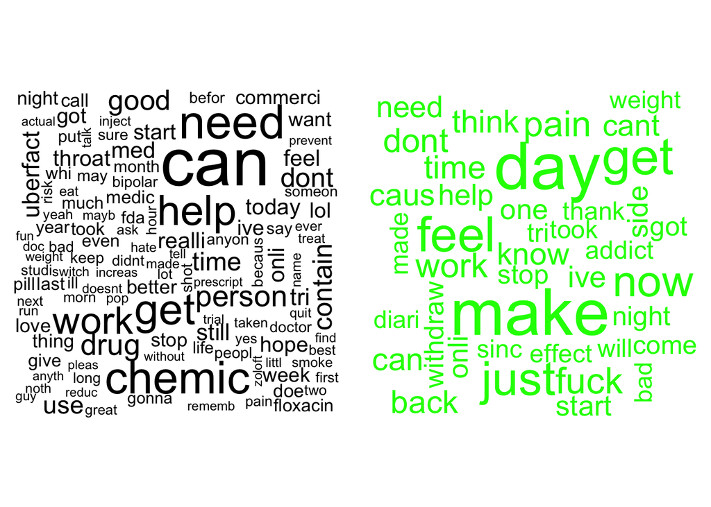

```r
par(mfrow = c(1, 2))
wordcloud(data[["train"]] %>% filter(is_AE == "No") %$% stemmed,
          min.freq = 20,
          random.color = TRUE,
          colors = "black"
          )

wordcloud(data[["train"]] %>% filter(is_AE == "Yes") %$% stemmed,
          min.freq = 20,
          random.color = TRUE,
          colors = "green"
          )
```

Next, we show the 30 most frequent words, both for tweets related to ADRs and tweets not related to ADRs.

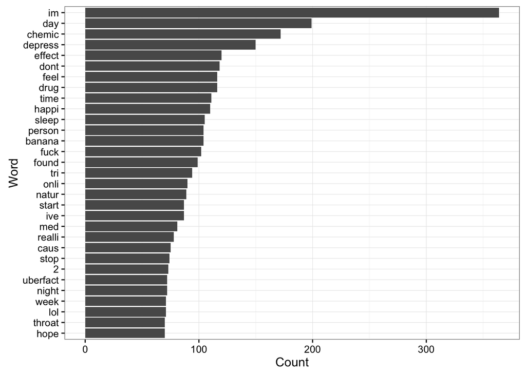

```r
data[[1]] %>%
    unnest_tokens(word, stemmed) %>%
    anti_join(stop_words, by = "word") %>%
    count(word) %>%
    top_n(30, n) %>%
    mutate(word = reorder(word, n)) %>%
    ggplot(aes(x = word, y = n)) +
    geom_bar(stat = "identity") +
    coord_flip() +
    xlab("Word") +
    ylab("Count")
```

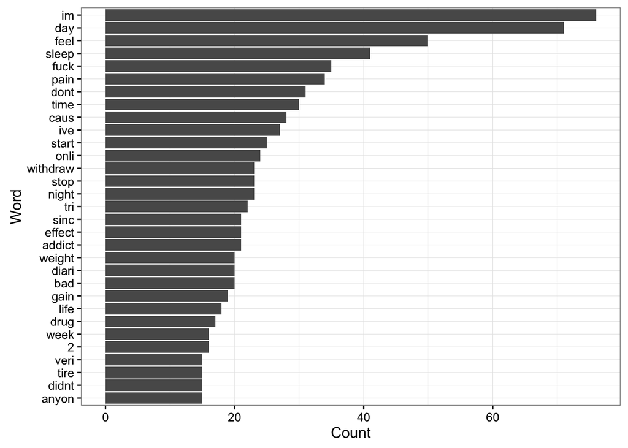

```r
data[[1]] %>%
    unnest_tokens(word, stemmed) %>%
    anti_join(stop_words, by = "word") %>%
    filter(is_AE == "Yes") %>%
    count(word) %>%
    top_n(30, n) %>%
    ungroup() %>%
    mutate(word = reorder(word, n)) %>%
    ggplot(aes(x = word, y = n)) +
    geom_bar(stat = "identity") +
    coord_flip() +
    xlab("Word") +
    ylab("Count")
```

Next, we take the `sentiments` data from the `tidytext` package to do sentiment analysis (we add these sentiments in addition to the ones mentioned in the data cleaning section, because they give a more refined picture of sentiments, and not only positive and negative). We see quite a big difference in sentiments between tweets corresponding to adverse events and those not corresponding to adverse events:

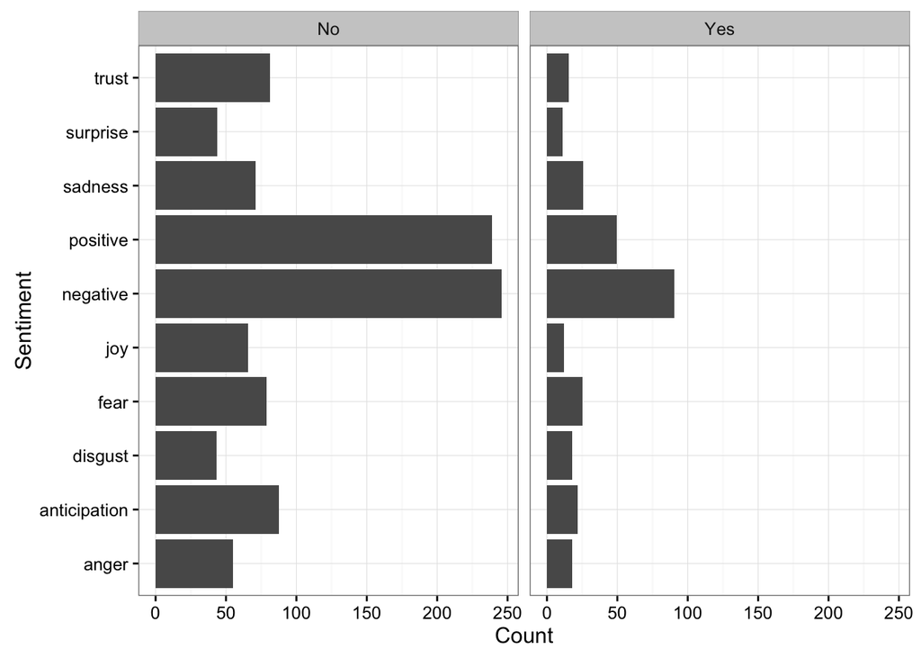

```r
data[[1]] %>%
    unnest_tokens(word, stemmed) %>%
    inner_join(sentiments, by = "word") %>%
    count(is_AE, sentiment) %>%
    group_by(is_AE) %>%
    mutate(n = n / n()) %>%
    ggplot(aes(x = sentiment, y = n)) +
    geom_bar(stat = "identity") +
    facet_wrap(~is_AE) +
    coord_flip() +
    xlab("Sentiment") +
    ylab("Count")
```

We also see that tweets correspoding to AEs tend to be slightly longer, though that criterion alone is of course insufficient (this hold true even more considering the imbalance of the dataset)

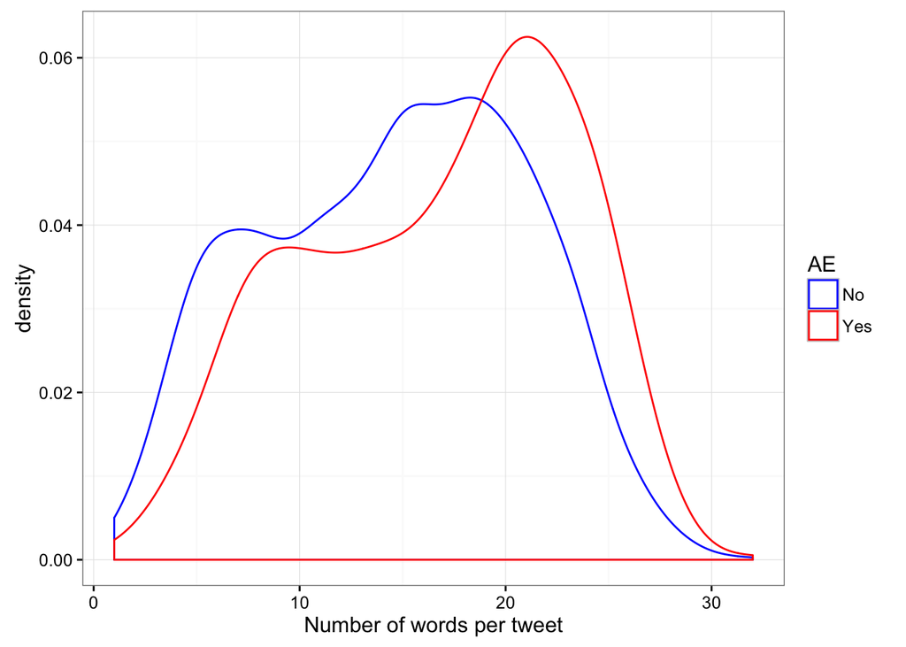

```r
data[[1]] %>%
    unnest_tokens(word, stemmed) %>%
    count(tweet_id, is_AE) %>%
    ggplot(aes(x = n, color = is_AE)) +
    geom_density() +
    xlab("Number of words per tweet") +
    scale_color_manual(values = c("Blue", "Red"),
                       name = "AE",
                       labels = c("No", "Yes"))
```

## First model: vector space model

We first train a model using the well known vector space model. In this model, the features correspond to **word count** (or other similarly constructed features).

### Document term matrx

The first step consists in preparing the **document term matrix** (DTM). This is a matrix whose columns corresponds to features of the text.

- Each word stem gives a feature, i.e. the feature matrix will have as many columns as there are distinct word stems in the corpus
- The value of each feature for each document (tweet) can be computed in various ways:
- one-hot-encoding: it is one if the word stem is in the tweet, 0 else
- Term frequency: the value of the feature is the number of times the word stem has occured in the tweet
- Term frequency inverse document frequency (*TfIdf*): this is a measure for the relative importance of the feature taking into account the frequency of the word stem in the entire corpus. For example, the word **the** may occur very frequently in a tweet, but it occurs also very often in the corpus. Thus its TfIdf will be low. On the other hand, if a word occurs often within a given tweet, but very rarely in the entire document, this means that the tweet is likely to be about this word and thus it obtains a high TfIdf.

We chose *Term Frequency* here to build the feature vectors. The reason is simple: the other approaches were tried, but using cross validation, Tf performed best.

```r
doc_matrix <- create_matrix(c(data[["train"]]$stemmed,
                              data[["test"]]$stemmed),
                            language = "english",
                            removeNumbers = TRUE,
                            removePunctuation = TRUE,
                            toLower = TRUE,
                            stemWords = TRUE,
                            stripWhitespace = TRUE,
                            ngramLength = 1,
                            minDocFreq = 1,
                            weighting = tm::weightTf)
```

### Container

Now that we have a DTM, we could use it directly as a feature matrix and train a model using, e.g. the `caret` package. The package `RTextTools`, however, has a very convenient datastructure allowing us to put all important data into one **container**. The main advantage is that we can keep using sparse matrices as opposed to e.g. the `tidytext` package. In the folowing code chunk, we put the tweets and the outcome in the container, specifying which data are training data and which data are test data. The option `virgin = FALSE` specifies that we have full information about the outcomes on the test data.

```r
container <-
    create_container(doc_matrix,
                     c(data[["train"]]$is_AE, data[["test"]]$is_AE),
                     trainSize = 1:nrow(data[["train"]]),
                     testSize = 1:nrow(data[["test"]]) + nrow(data[["train"]]),
                     virgin = FALSE)
```

### Model training

Using the container described above, we can directly train models. Here, we train four different models (training the other models is quite slow and does not significantly improve the performance) using the standard parameters:

- MAXENT: Maximum Entropy
- GLMNET: this is a regularized version of logistic regression
- SVM: regularized support vector machine
- TREE: decision tree

```r
fit_models <-
    train_models(container,
                 c("MAXENT", "GLMNET", "SVM", "TREE"),
                 cost = 1000)
```

## Model prediction

The `RTextTools` package also allows us to make predictions quite easily. The following code chunk produces the results (i.e. predicted probability and predicted label) for each of the four models on the test set:

```r
preds <- classify_models(container, fit_models)
```

## Model evaluation

The next step is to evaluate the quality of the models. We start with AUC:

```r
par(mfrow = c(2, 2))
preds %$% roc(data[["test"]]$is_AE, MAXENTROPY_PROB) %>% plot
```

```
##
## Call:
## roc.default(response = data[["test"]]$is_AE, predictor = MAXENTROPY_PROB)
##
## Data: MAXENTROPY_PROB in 960 controls (data[["test"]]$is_AE No) > 256 cases (data[["test"]]$is_AE Yes).
## Area under the curve: 0.554
```

```r
preds %$% roc(data[["test"]]$is_AE, GLMNET_PROB) %>% plot
```

```
##
## Call:
## roc.default(response = data[["test"]]$is_AE, predictor = GLMNET_PROB)
##
## Data: GLMNET_PROB in 960 controls (data[["test"]]$is_AE No) > 256 cases (data[["test"]]$is_AE Yes).
## Area under the curve: 0.8175
```

```r
preds %$% roc(data[["test"]]$is_AE, SVM_PROB) %>% plot
```

```
##
## Call:
## roc.default(response = data[["test"]]$is_AE, predictor = SVM_PROB)
##
## Data: SVM_PROB in 960 controls (data[["test"]]$is_AE No) > 256 cases (data[["test"]]$is_AE Yes).
## Area under the curve: 0.7945
```

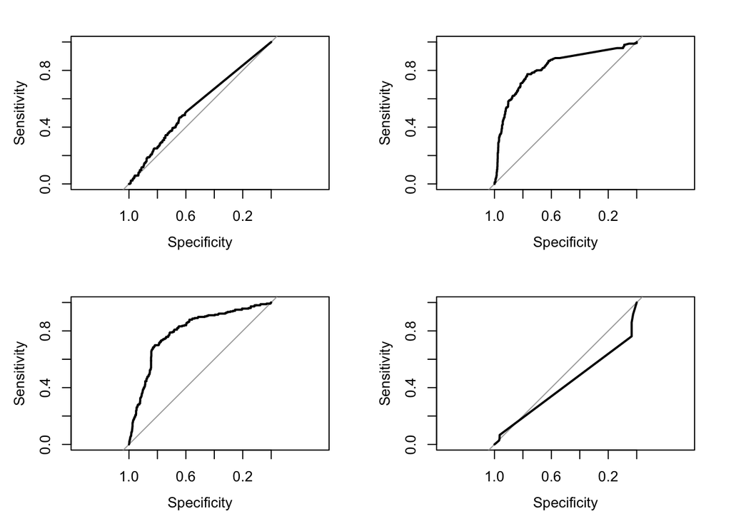

```
##
## Call:
## roc.default(response = data[["test"]]$is_AE, predictor = TREE_PROB)
##
## Data: TREE_PROB in 960 controls (data[["test"]]$is_AE No) < 256 cases (data[["test"]]$is_AE Yes).
## Area under the curve: 0.4181
```

```r
preds %$% roc(data[["test"]]$is_AE, TREE_PROB) %>% plot
```

We see that the regularized logistic regression performs best with quite a high area under the curve.

Next, the `RTextTools` package allows us to extract important other measures as well quite easily using the `create_analytics` command. This gives us the precision, recall and f-score for each of the models (recall that the f-score is a weighted average of the precision and the recall).

Also it automatically creates an **ensemble summary**. This is a useful statistics about the combined performance of all four models. The line corresponding to, e.g. `n >= 2` means the following:

- Coverage tells us on how many percent of the documents two ore more models agree.
- The recall value corresponds to the recall statistics when restricted to those documents.

```r
analytics <- create_analytics(container, preds)
summary(analytics)
```

```
## ENSEMBLE SUMMARY
##
##        n-ENSEMBLE COVERAGE n-ENSEMBLE RECALL
## n >= 1                1.00              0.85
## n >= 2                1.00              0.85
## n >= 3                0.95              0.88
## n >= 4                0.77              0.92
##
##
## ALGORITHM PERFORMANCE
##
##        SVM_PRECISION           SVM_RECALL           SVM_FSCORE
##                0.845                0.700                0.740
##     GLMNET_PRECISION        GLMNET_RECALL        GLMNET_FSCORE
##                0.860                0.670                0.705
##       TREE_PRECISION          TREE_RECALL          TREE_FSCORE
##                0.755                0.630                0.655
## MAXENTROPY_PRECISION    MAXENTROPY_RECALL    MAXENTROPY_FSCORE
##                0.740                0.760                0.750
```

From this, it seems quite plausible that stacking these models can make sense.

## Other inputs

We trained a second model and used the output of this to build a stacked model.

The “right” way would actually be to simply column bind these new features to the bag of words matrix. This can be done, but it should also be done using sparse matrices, otherwise, we have to reduce the dimension of the bag of words matrix (i.e. use fewert words as features). This is why we did not use the `tidytext` package here (it was tried, but the performance is worse if the number of terms is restricted).

Here, we just outline how a second model can be trained: we do basic preprocessing. Here, we compute the sentiments by using the dataset from the `tidytext` package.

```r
preprocess_second <- function(my_data) {
    sentiments_tweets <-
        my_data %>%
        unnest_tokens(word, stemmed) %>%
        left_join(sentiments %>% mutate(word = stemDocument(word)),
                   by = "word") %>%
        count(tweet_id, sentiment) %>%
        mutate(sentiment = str_c("sentiment_", sentiment)) %>%
        filter(!is.na(sentiment)) %>%
        spread(sentiment, n, fill = 0)

    res <- left_join(my_data %>% select(tweet_id),
                     sentiments_tweets,
                     by = "tweet_id")

    res[is.na(res)] <- 0

    left_join(my_data, res, by = "tweet_id") %>%
        mutate(tweet_length = str_length(stemmed))

}

train_2nd <- preprocess_second(data[[1]])
cv_2nd <- preprocess_second(data[[2]])
```

```r
fit_2nd <- train(is_AE ~ .,
                 data = train_2nd %>% select(starts_with("sentiment"),
                                             tweet_length,
                                             is_AE),
                 trControl = trainControl(method = "cv",
                                          number = 5,
                                          p = 0.75),
                 method = "rf")

par(mfrow = c(1, 1))
preds$model_two <- predict(fit_2nd, newdata = cv_2nd, type = "prob")[, 2]
fit_2nd
```

```
## Random Forest
##
## 3274 samples
##   11 predictor
##    2 classes: 'No', 'Yes'
##
## No pre-processing
## Resampling: Cross-Validated (5 fold)
## Summary of sample sizes: 2619, 2620, 2619, 2619, 2619
## Resampling results across tuning parameters:
##
##   mtry  Accuracy   Kappa
##    2    0.8066592  0.02892113
##    6    0.7941364  0.03363507
##   11    0.7932194  0.05831236
##
## Accuracy was used to select the optimal model using  the largest value.
## The final value used for the model was mtry = 2.
```

```r
varImp(fit_2nd)
```

```
## rf variable importance
##
##                        Overall
## tweet_length           100.000
## sentiment_negative      69.193
## sentiment_positive      51.563
## sentiment_sadness       22.008
## sentiment_fear          15.432
## sentiment_anticipation  10.973
## sentiment_trust         10.659
## sentiment_disgust        9.602
## sentiment_anger          9.279
## sentiment_joy            4.993
## sentiment_surprise       0.000
```

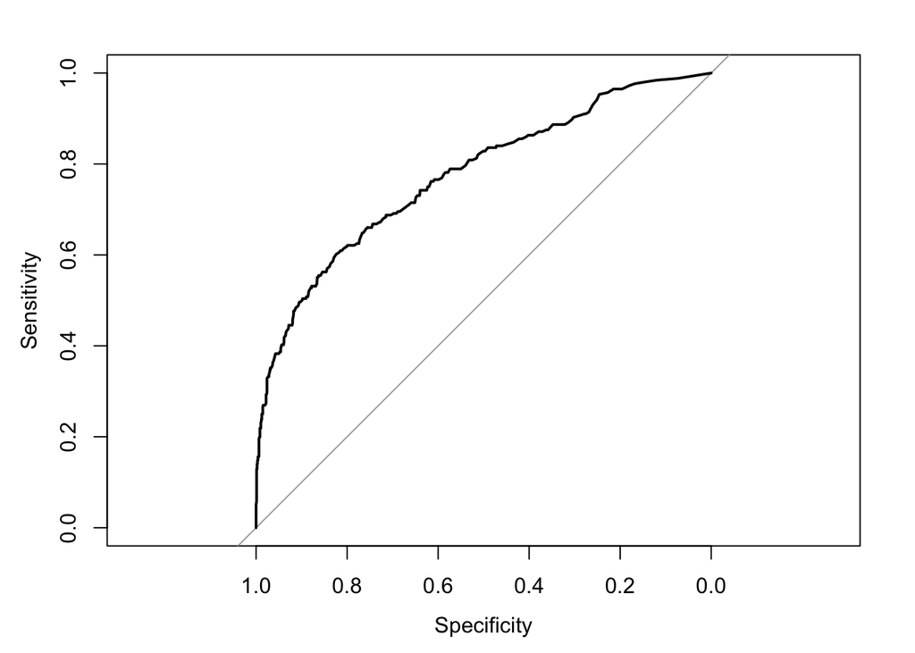

```
##
## Call:
## roc.default(response = cv_2nd$is_AE, predictor = preds$model_two)
##
## Data: preds$model_two in 960 controls (cv_2nd$is_AE No) < 256 cases (cv_2nd$is_AE Yes).
## Area under the curve: 0.7743
```

```r
pROC::roc(cv_2nd$is_AE, preds$model_two) %>% plot
```

As we saw in the exploratory part of the analysis, `tweet_length` is a good predictor, as well as the positive and negative sentiments.

The area under curve is actually quite good for a model with so few features (just think what we did in terms of dimension reduction: we reduced from roughly 8000 dimensions to roughly 10 dimensions with relatively little reduction in predictive performance!)

## Aggregating predictions:

The next step is to aggregate the predictions from different models into a final model. We use the outputs from the previous models as inputs and train a random forest.

```r
preds$results <- data[["test"]]$is_AE
tr_control <- trainControl(method = "cv",
                           number = 10,
                           summaryFunction = twoClassSummary,
                           classProbs = TRUE)

tune_grid <- expand.grid(mtry = c(1, 2, 3, 4))

fit_rf <- train(results ~ MAXENTROPY_PROB + GLMNET_PROB + SVM_PROB +
                    TREE_PROB + model_two,
               data = preds,
               method = "rf",
               trControl = tr_control,
               tuneGrid = tune_grid,
               metric = "ROC"
)
```

We look at the results:

```r
fit_rf
```

[output not shown]

```r
varImp(fit_rf)
```

```
## rf variable importance
##
##                  Overall
## GLMNET_PROB     100.0000
## SVM_PROB         87.1144
## model_two        84.2441
## TREE_PROB         0.3804
## MAXENTROPY_PROB   0.0000
```

The area under curve is around 85%, which is quite high.

# Recent data

The next step consists in checking whether we can reproduce these results with recently collected twitter data. We decided to focus on the bag of words model.

In order for the following code chunk to work, this [hack](https://groups.google.com/forum/embed/#!topic/rtexttools-help/Drqr3Z897Mk) has to be performed.

We plot the receiver-operating characteristic for the new tweets.

```r
source("../r/clean_tweets.R")
source("../r/make_drug_list.R")
source("../r/make_slang_lookup.R")
source("../r/helper_functions/create_matrix_fixed.R")

cleaned_tweet <-
    read.xlsx("../data/download_tweets/tweets_recent_annotated.xlsx",
              sheetIndex = 1) %>%
    select(tweet_id, tweet_text, is_AE) %>%
    clean_tweets(make_drug_list(), make_slang_lookup())


source("../r/helper_functions/create_matrix_fixed.R")
new_tweets_dtm <-
    create_matrix(cleaned_tweet$stemmed,
                  originalMatrix = doc_matrix,
                  language = "english",
                  removeNumbers = TRUE,
                  removePunctuation = TRUE,
                  toLower = TRUE,
                  stemWords = TRUE,
                  stripWhitespace = TRUE,
                  ngramLength = 1,
                  minDocFreq = 1,
                  weighting = tm::weightTf)

new_container <- create_container(new_tweets_dtm,
                                  labels = c(data[[1]]$is_AE, data[[2]]$is_AE,
                                             cleaned_tweet$is_AE),
                                  trainSize = NULL,
                                  testSize = 1:nrow(cleaned_tweet),
                                  virgin = FALSE
)

preds_new <- classify_models(new_container, fit_models)


# Sentiment model
cleaned_tweet_two <- cleaned_tweet %>% preprocess_second

# Add sentiment variables not in data frame
all_sentiments <-
    sentiments %$%
    sentiment %>%
    keep(~!is.na(.)) %>%
    unique %>%
    map_chr(~str_c("sentiment_", .))

sentiments_not_present <-
    keep(all_sentiments, ~(!. %in% colnames(cleaned_tweet_two)))

cleaned_tweet_two[, sentiments_not_present] <- 0

# Predict second model
preds_new$model_two <-
    predict(fit_2nd, cleaned_tweet_two, type = "prob")[, 2]

analytics <- create_analytics(new_container, preds_new)
print(summary(analytics))
```

[output not shown]

```r
par(mfrow = c(1, 2))
preds_new %$% pROC::roc(cleaned_tweet$is_AE, GLMNET_PROB) %>% plot
```

```
##
## Call:
## roc.default(response = cleaned_tweet$is_AE, predictor = GLMNET_PROB)
##
## Data: GLMNET_PROB in 319 controls (cleaned_tweet$is_AE 0) > 76 cases (cleaned_tweet$is_AE 1).
## Area under the curve: 0.6838
```

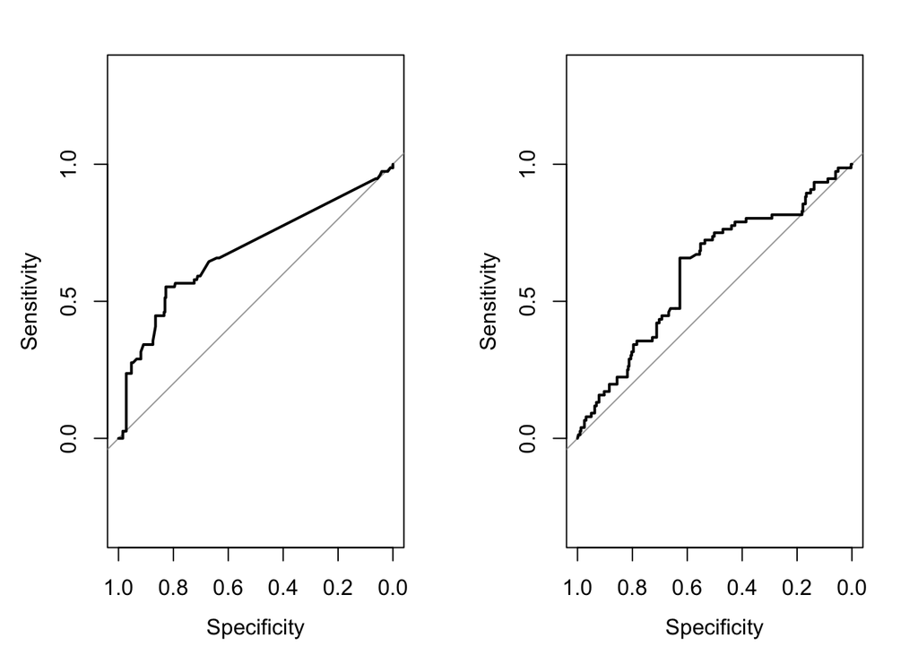

```
##
## Call:
## roc.default(response = cleaned_tweet$is_AE, predictor = SVM_PROB)
##
## Data: SVM_PROB in 319 controls (cleaned_tweet$is_AE 0) > 76 cases (cleaned_tweet$is_AE 1).
## Area under the curve: 0.6124
```

```r
preds_new %$% pROC::roc(cleaned_tweet$is_AE, SVM_PROB) %>% plot
```

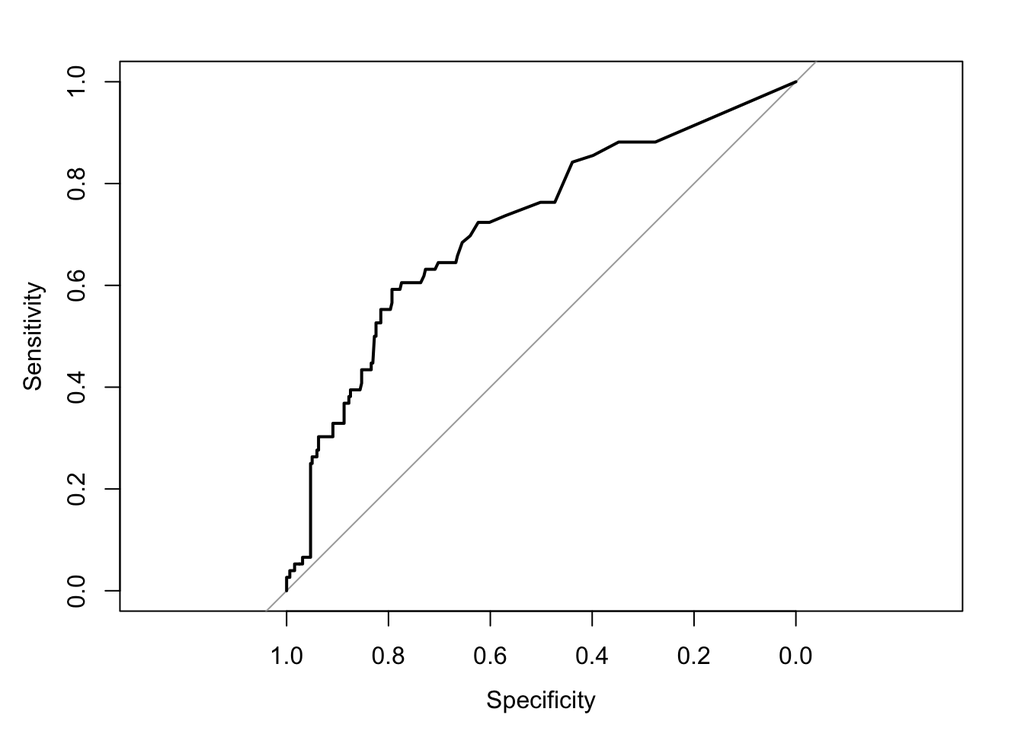

```
##
## Call:
## roc.default(response = cleaned_tweet$is_AE, predictor = preds_new_final)
##
## Data: preds_new_final in 319 controls (cleaned_tweet$is_AE 0) < 76 cases (cleaned_tweet$is_AE 1).
## Area under the curve: 0.7144
```

```r
par(mfrow = c(1, 1))
preds_new_final <- predict(fit_rf, preds_new, type = "prob")[, 2]
pROC::roc(cleaned_tweet$is_AE, preds_new_final) %>%
    plot()
```

We see that the result is quite a bit worse, but still much better than random. In particular, the support vector machine had a huge drop in performace.

A very likely reason is that our way of manually annotating tweets is different from the researchers in [here](http://diego.asu.edu/Publications/ADRMine.html) and [here](http://diego.asu.edu/downloads/twitter_annotated_corpus/): they had meetings with experts that went very carefully over all tweets. On the other hand, it is not even clear how good our area under curve as annotators would be.

## Save models

```r
save(fit_models, file = "../data/models/fit_models.RData")
save(fit_rf, file = "../data/models/stacked_rf.RData")
save(doc_matrix, file = "../data/models/doc_matrix.RData")
save(data, file = "../data/models/train_data.RData")
save(fit_2nd, file = "../data/models/sentiment_model.RData")
```

# Comorbidity

The comorbidity, or co-occurrence of Adverse Events can show trends and help determine causal relationships of Drug Related Adverse Events [(Wang et al, 2009)](https://www.ncbi.nlm.nih.gov/pubmed/23703825/)

Furthermore, the co-occurence patterns of Adverse events, particularly under co-administration of multiple drugs is poorly understood.

Here we will examine the use of social networking algorithms to detect co-occuring adverse events.

## Data collection

Initially we hoped to use the tweet data from previous sections for this analysis. However we simply did not have enough data points available.

The FDA provides quarterly downloadable files of Adverse Events reported for use in post-marketing safety surveillance from [here](http://www.fda.gov/Drugs/GuidanceComplianceRegulatoryInformation/Surveillance/AdverseDrugEffects/). We consequently decided that this was a clean, abundant and reliable source of data to perform the analysis on.

### A First look at the data

Reading in the Adverse Events, and the drugs the patients were on.

```r
#A First look at the data

require(knitr)
require(dplyr)
require(ggplot2)
require(rafalib)
require(igraph)

# Adverse Event data
ae.data <- read.delim2("../data/REAC15Q4.txt",sep="$", stringsAsFactors = FALSE)

# Associated drug data
drug.data <- read.delim2("../data/DRUG15Q4.txt",sep="$", stringsAsFactors = FALSE)
```

The Drug data contains information on repeat dosing, as well as missed doses. We will only keep patients that had an actual dose of study drug and that the drug was the primary suspect of the AE.

```r
drug.data <- drug.data %>%
  filter(cum_dose_chr !="" && role_cod =="PS") %>%
  select(primaryid, drugname) %>%
  unique()

# Print the drugs with the most patients
drug.data %>%
  group_by(drugname)%>%
  summarize(n=n())%>%
  arrange(-n) %>%
  head %>%
  kable
```

| drugname | n |
| --- | --- |
| FORTEO | 31811 |
| ENBREL | 15436 |
| ASPIRIN. | 8189 |
| REVLIMID | 7395 |
| PREDNISONE. | 6353 |
| XARELTO | 6284 |

```r
#How many incidences does vyvanse have
drug.data %>%
  filter(tolower(drugname)=="vyvanse") %>%
  group_by(drugname) %>%
  summarize(n=n())%>%
  arrange(-n) %>%  kable
```

| drugname | n |
| --- | --- |
| VYVANSE | 542 |

We can see that there are a lot of patients here, and it would be very tricky to visualise graphs of these sizes, so for this analysis, we will look specifically at Vyvanse. This was the most frequent drug on the tweet analysis section.

Similary, taking a look at the Adverse event dataset, we will keep only those where the primary suspect is Vyvanse.

```r
# Get an idea of how many data points we are looking at in the total AE dataset
ae.data %>%
  summarize(n_patients = n_distinct(primaryid),
            n_aes      = n_distinct(pt))
```

```
##   n_patients n_aes
## 1     314858 10451
```

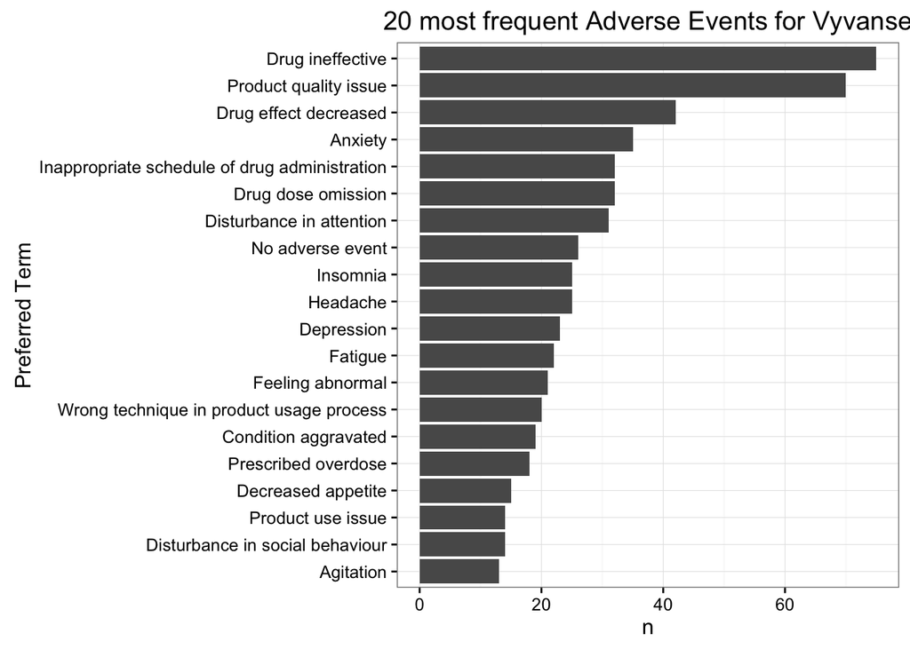

```r
# Select only vyvanse patients
vyvanse <- drug.data %>%
  filter(tolower(drugname)=="vyvanse") %>%
  select(primaryid) %>%
  unique()

# Filter the AE dataset for these patients
ae.data.subset <- ae.data %>%
  filter(primaryid %in% vyvanse$primaryid)

# plot the frequencies of the 20 most common AEs
counts <- count(ae.data.subset,pt) %>%
  arrange(-n) %>%
  head(20)

ggplot(counts, aes(x = reorder(pt, n), y = n)) +
         geom_bar(stat = "identity") +
         xlab("Preferred Term") +
         ggtitle ("20 most frequent Adverse Events for Vyvanse") +
  coord_flip()
```

### Building the network graph

We will start by creating an adjacency list to build the graph object. We will also add weights to each of the edges where the weight will be the probability of that edge (1/number of edges) for that patient.

```r
# We will only consider at most, one co-occurence of Adverse Events per patient

# Calculate the number of AEs per patient
ae.data.obs <-ae.data.subset %>%
  dplyr::select(primaryid, pt) %>%
  group_by(primaryid) %>%
  mutate(obs=n()) %>%
  ungroup

# Cartesian product of adverse events, we reduce this so we are not double counting edges. ie A->B != B->A
ae.data.expand <- ae.data.obs %>% full_join(ae.data.obs,by="primaryid") %>%
  filter (pt.x<pt.y) %>%
  mutate(from=pt.x, to=pt.y, wgt=1/obs.x) %>%
  group_by(from, to)%>%
  summarise(weight=sum(wgt)) %>%
  ungroup

# Build the graph object from the data
g <- graph.data.frame(ae.data.expand, directed = FALSE)
```

Now that we have our graph object, we will assign the frequencies of the Adverse events to the nodes.

We will then do some simple interrogation of the graph.

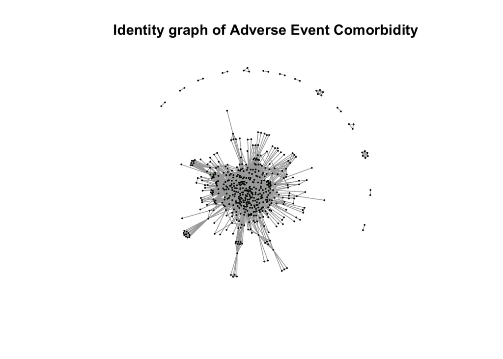

```r
# Calculate the frequency of each Adverse Event
pt.freq <- ae.data.obs %>%
  group_by(pt) %>%
  summarise(nc=n()) %>%
  ungroup

# Match the AE frequencies to their ordering in the Graph object
name.ord <- data.frame(names=V(g)$name,ord=seq(1:length(V(g)$name))) %>%
  left_join(pt.freq, by=c("names"="pt")) %>%
  arrange(ord)

# Apply the frequencies to be the node counts
V(g)$node_count <- name.ord$nc

# Preliminary plot to see the structure of the graph
plot(g,
     main="Identity graph of Adverse Event Comorbidity",
     vertex.label=NA,
     vertex.size=1,
     vertex.color="green")
```

```r
# Number of vertices
vcount(g)
```

```
## [1] 511
```

```r
# Number of edges
ecount(g)
```

```
## [1] 3577
```

We can see from our preliminary plot that we have one large cluster of AEs, and a few very small clusters as well as a few isolates that consist of only one edge.

### Cluster analysis

Lets first take a look at some of the smaller clusters and isolates.

```r
# We don't expect all our Adverse events to be connected, so taking a look at the number of distinct clusters
g.components <- clusters(g)

# print sizes of each cluster
g.components$csize
```

```
##  [1] 474   2   6   5   3   2   3   2   2   2   2   2   2   2   2
```

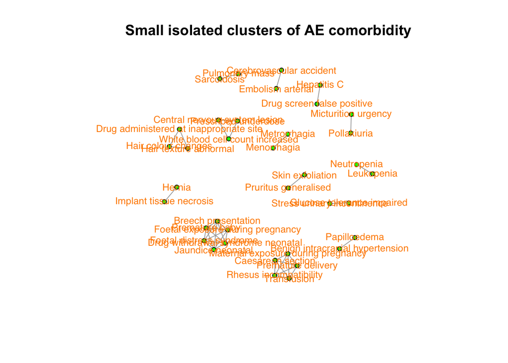

```r
# We can see that we have one large cluster of 474, 4 small and 10 isolates that consist of a single unconnected pair.

# Lets plot the small clusters together
g.small <- induced.subgraph(g, which(g.components$membership != which.max(g.components$csize)))

#Edges have been weighted by the degree
g.small.layout <-  layout.reingold.tilford(g.small, circular=TRUE)
plot(g.small,
     main="Small isolated clusters of AE comorbidity",
     vertex.size = 4,
     vertex.color ="green",
     vertex.label.family = "sans",
     vertex.label.cex = .8,
     vertex.label.color ="darkorange"
     )
```

```r
# Isolates with small degrees are likely either rare or due to chance and have little to do with the Drug
```

It’s hard to see the groupings properly above, so we will focus on the two main groups of interest.

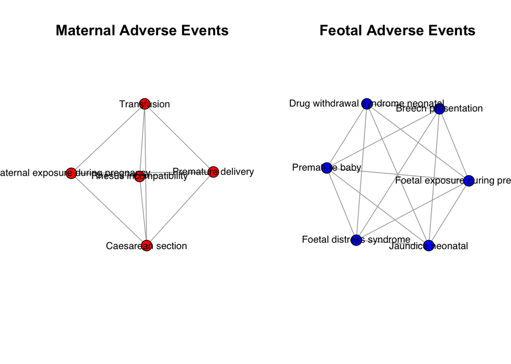

```r
plot_subgraph <- function(gr, title,color){
   plot(gr,
     main=title,
     #vertex.size = 4,
     vertex.color =color,
     vertex.label.family = "sans",
     vertex.label.cex = .8,
     vertex.label.color ="black"
     )
}

g.mother <- induced.subgraph(g, which(g.components$membership == 4))
g.child <- induced.subgraph(g, which(g.components$membership == 3))

par(mfrow=c(1,2))
plot_subgraph(g.mother,"Maternal Adverse Events","red")
plot_subgraph(g.child,"Feotal Adverse Events","blue")
```

```r
par(mfrow=c(1,1))

# We will continue the rest of the analysis keeping only the large central network
g.big <- induced.subgraph(g, which(g.components$membership == which.max(g.components$csize)))
```

We can see some interesting groupings from the small clusters already. One cluster points to neonatal AEs such as : - Jaundice Neonatal - Premature baby - Feotal exposure during pregnancy - Drug withdrawal sympton neonatal - Feotal distress syndrome

### Community detection

```r
set.seed(1234)
# Detecting community strucution via short random walks
wc <- walktrap.community(g.big, weights = E(g.big)$weight, steps = 120, merges =
          TRUE, modularity = TRUE, membership = TRUE)

# Print the sizes of our communities
sizes(wc)
```

```
## Community sizes
##   1   2   3   4   5   6   7   8   9  10  11  12  13  14  15  16  17  18
##  11   2   2 141  42  40  78  98   7   5  10   2   2   3   7   7   4   3
##  19  20  21  22  23  24  25  26  27  28
##   1   1   1   1   1   1   1   1   1   1
```

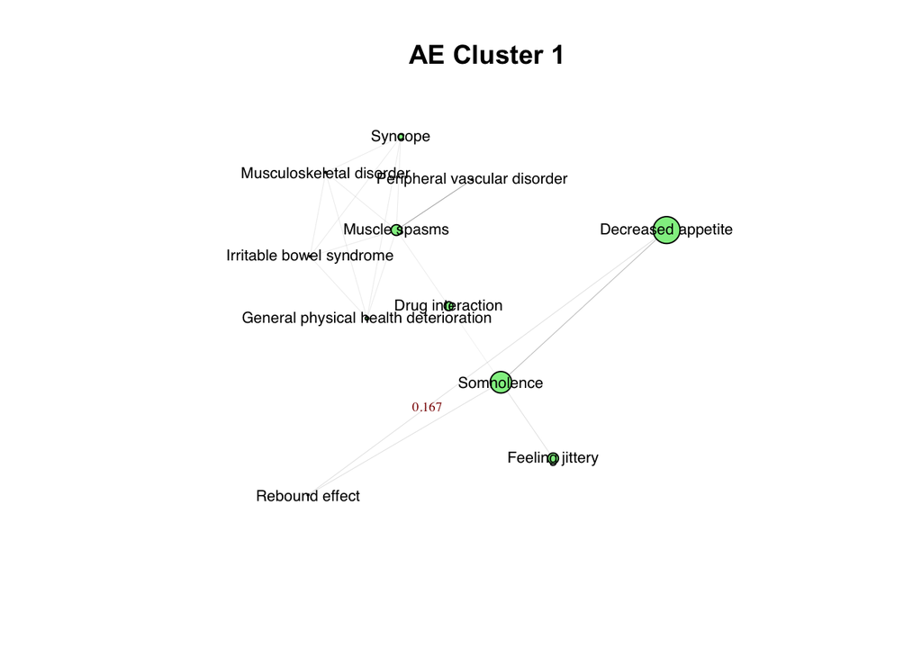

```r
plot_cluster <- function(clust,title, edges=FALSE){
  g.prune <- induced.subgraph(g.big, which(membership(wc)==clust))
  g.prune.layout <-  layout.reingold.tilford(g.prune,circular=TRUE)

  plot(g.prune,
     main = title,
     layout =g.prune.layout,
     vertex.size = (V(g.prune)$node_count),
     vertex.color ="lightgreen",
     vertex.label.cex = .7,
     vertex.label.family = "sans",
     vertex.label.color ="black",
     edge.label = ifelse(edges,round(E(g.prune)$weight,3),NA),
     edge.label.cex = .6,
     edge.label.color = "darkred",
     edge.width = E(g.prune)$weight)

}

plot_cluster(1,"AE Cluster 1",edges=TRUE)
```

In the above graphs, the size of the node represents the frequency of that AE. The edge weight is given by the sum of probabilies of the co-occurence of the two connected AEs. For example, we can see in cluster 1 that a decreased appetite and somnolence are quite common on vyvanse and having a decreased appetite if you have somnolence is more likely than experiencing feeling jittery.

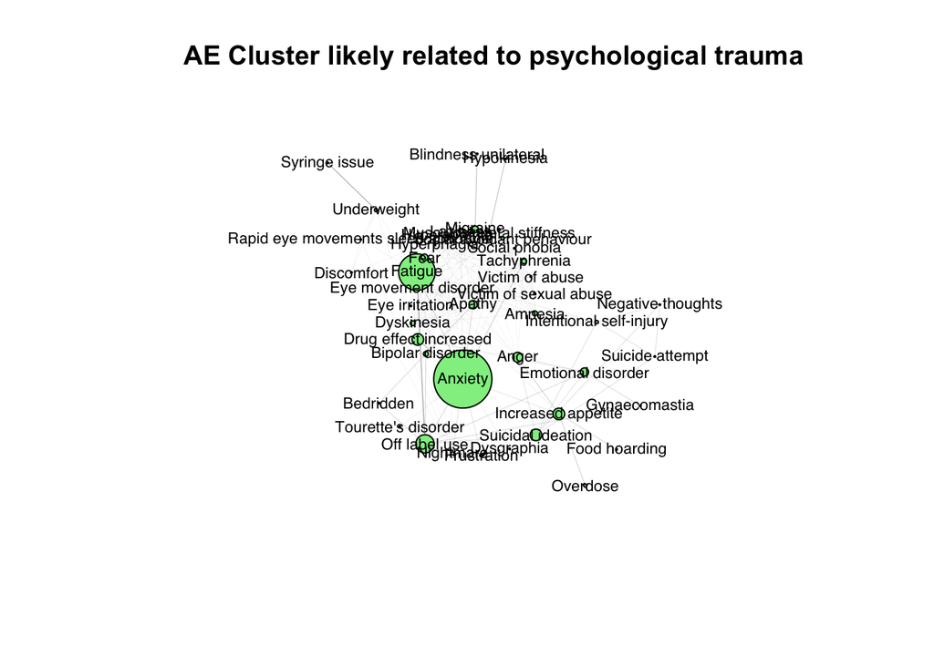

```r
plot_cluster(5,"AE Cluster likely related to psychological trauma")
```

Cluster 5 looks shows terms mostly to do with psychological trauma. Bipolar disorder, suicidal ideation and fatigue are known to be strongly linked and we can see this here also.

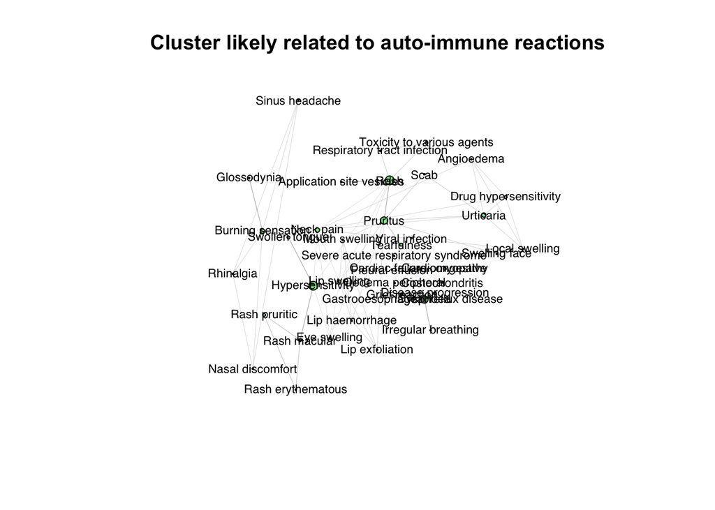

```r
plot_cluster(6,"Cluster likely related to auto-immune reactions")
```

Cluster 6 seems to primarily be auto-immune reactions.

We will now look at the last cluster in a heatmap

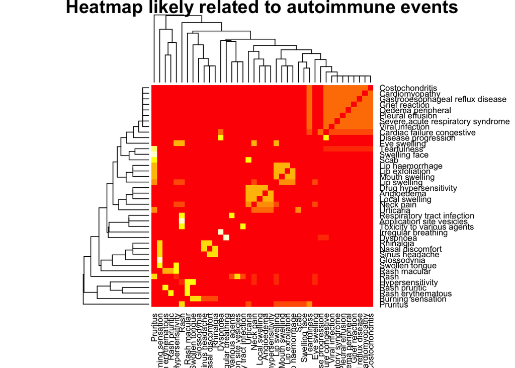

```r
plot_heat <- function(clust){
    g.prune <- induced.subgraph(g.big, which(membership(wc)==clust))
    e <- get.adjacency(g.prune,attr="weight")
    e <- e+0.001 #getting rid of nas
    heatmap(as.matrix(e),
            main = "Heatmap likely related to autoimmune events")

}

plot_heat(6)
```

From the heatmap we can see clustering and labels a bit better, and there are 3-4 clusters. In general, throughout the analysis, adverse events of similar clinical groupings have been clustering together. We suspected this might be the case, but the clustering has done a better than expected job of grouping the AE terms.

# Conclusion

## Predicting Adverse events from tweets

With quite sophisticated data cleaning techniques and stacking of machine learning models, we were able to reproduce the order of predictive performance obtained in previous related work.

When the model was applied to new data, the predictive performance dropped significantly, but it was still highly significantly (statistically and practically) above random performance. One reason for this is that we do not have the same experience and methodology of previous researchers for annotating the tweets.

Other possible reasons are that tweets containing drug names have changed. There are some plausible explanations in what way tweets change over time:

- The number of advertisements grows in proportion
- Slang words change
- The use of twitter overall changes

Answering what exactly caused the predictive performance to drop is another interesting project. A first step in this direction would be to compute our accuracy for manually annotated tweets, i.e. manually annotate some tweets that are in the training and validation sets and compute agreement.

Next steps would be to do simple exploratory analyses on the new data set:

- Are the most frequent words the same?
- Does the sentiment profile look similar?
- Are there more names of URLs contained in the more recent dataset?
- …

## Comorbidity

From clustering using social network techniques, we observed groupings of Adverse Events similar to what we would have under a heirachical drug term dictionary like MedDra. Although this was a simple case where we only considered one drug and ignored probable confounding factors like demographic data or concomitant medications, the results were very plausible.

The next step would be to classify the preferred terms under a heirachical drug dictionary, so we could focus on the Adverse Events that were “out of place”. That would also be useful in identifying unnexpected relationships that are difficult to detect in a clinical setting (eg, multiple concomitant drugs).

A very interesting extension of the comorbidity analysis would be to work on the **bipartite graph**. There we have two sets of nodes:

1. Patients
2. Adverse Events

Edges between patients and adverse events occur, if a patient is marked with an adverse events. This graph has the advantage of containing all the informations needed to calculate cooccurence probabilities:

- The degree, i.e. the number of outgoing edges, of an AE node $A$, $d(A)$, corresponds to the number of times $A$ has occured
- The number of length two paths between two AE nodes $A$ and $B$ $n(A,B)$ corresponds to the number of cooccurences of $A$ and $B$
- Thus the cooccurence probability of $A$ and $B$ is $p(A\vert B) = n(A, B) / d(B)$

This is actually very strongly related to the concept of **association rule mining** on the graph, which could lead to similiar results.

Other interesting analyses could be similar to recommender systems for use by a physician: a recommender system can be thought of as a bipartitge graph. That is, given a list of medications that the patient is on, and by specifying also which AEs the patient alread has observed through user-user collaborative filtering, we could suggest what are the most likely adverse events based on the ones a patient already has. “Recommending an AE” in this case would correspond to suggesting diagnostic tests (in terms of graphs, this corresponds to link prediction).